# Chap11

## Case study

We study the distribution of the vegetation of Carpathian wetlands . The occurrences about vegetation of $30$ bryophytes plants together with environmental variables, recorded in $16 \ \text{m}^2$ plots from 70 fens (1 plot per locality) in the borderland between the Czech Republic and Slovakia. Water samples for consequent chemical analysis were taken in microsites best supplied by water from the central part of the fen, to obtain 14 chemical parameters of water ($Ca$, $Mg$, $Fe$, $K$, $Na$, $Si$, $SO_4$, $PO_4$, $NO_3$, $NH_3$, $Cl$, $Corg$, $pH$ and conductivity).

```r
rm(list=ls())
library(factoextra)
library(Hmsc)
library(knitr)
library(corrplot)

#data download
bryo <- read.delim ('https://raw.githubusercontent.com/zdealveindy/anadat-r/master/data/bryophytes.txt', row.names = 1)
vasc <- read.delim ('https://raw.githubusercontent.com/zdealveindy/anadat-r/master/data/vasc_plants.txt', row.names = 1)
chem <- read.delim ('https://raw.githubusercontent.com/zdealveindy/anadat-r/master/data/chemistry.txt', row.names = 1)

X<-as.data.frame(apply(chem[,1:14],MARGIN=2, scale))
attach(X)

set.seed(17121993)

# info of data here: https://www.davidzeleny.net/anadat-r/doku.php/en:data:wetlands
```

## Select variables

We apply a PCA to select the predictors. We choose $Corg$, $Mg$, $K$, $conduct$ after the PCA analyisis. We split the dataset to obtain a train and a test dataset ($70 \%$ and $30\%$ respectively).

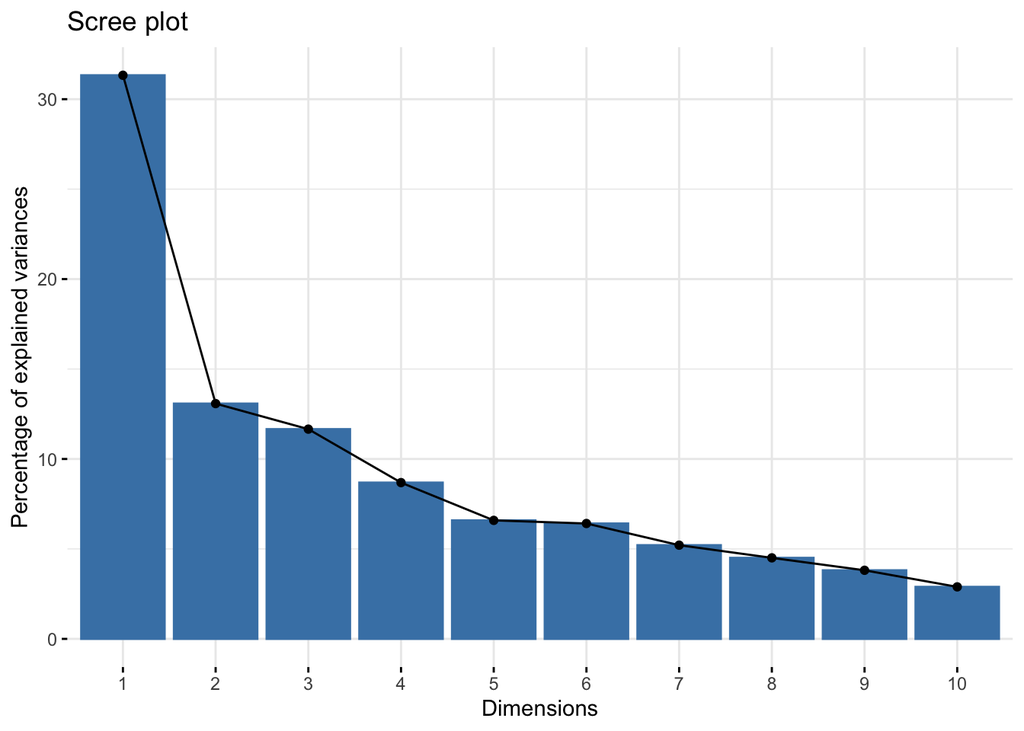

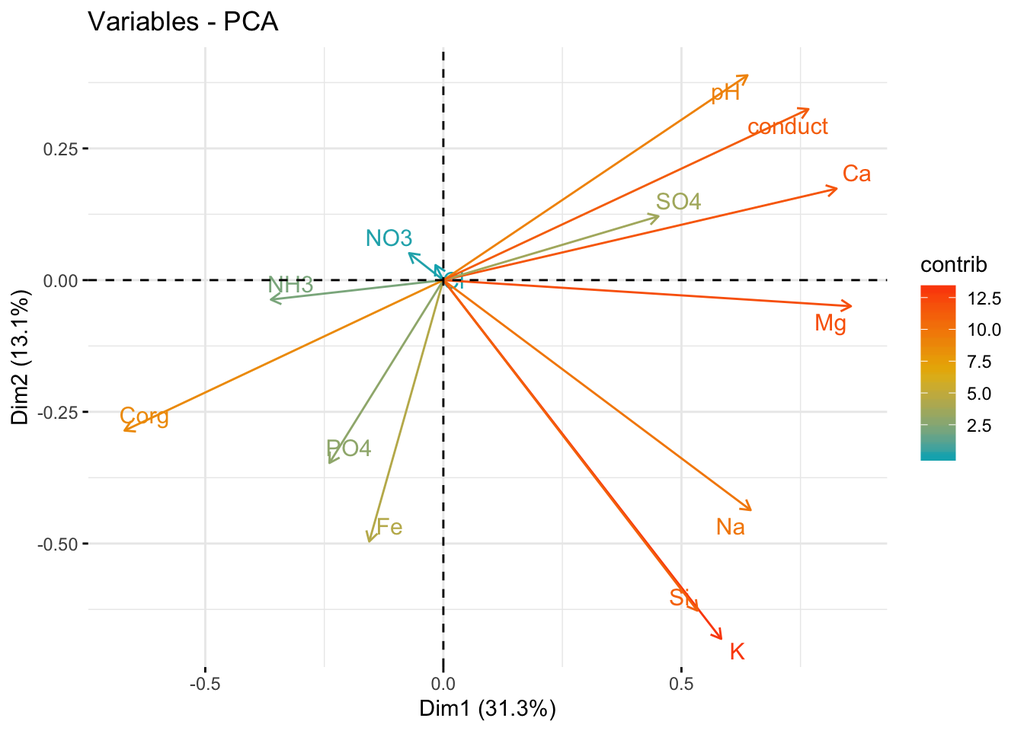

## Model definition

We include the quadratic terms of each variable to allow for local optima. We choose to model the response data with the Poisson distribution since we are modelling counts.

```r
XFormula = ~ poly(Corg,degree=2) + poly(Mg,degree=2) + poly(K,degree=2) + poly(conduct, degree=2)

studyDesign = data.frame(sample = as.factor(1:nrow(Y_train)))
rL = HmscRandomLevel(units = studyDesign$sample)

m = Hmsc(Y = Y_train,
       XData = X_train, XFormula = XFormula, ,ranLevels = list(sample = rL), studyDesign = studyDesign,
       distr = "poisson")
```

## MCMC run

We run two chains of the MCMC sampler, thinned to keep one every 10 samples, with 1000 elements of burn-in for a sample size of 20 00 .

```r
thin = 10
samples = 1000
nChains = 2

m = sampleMcmc(m, samples = samples, thin = thin,
               transient = 1000, nChains = nChains,verbose=1000, nParallel = nChains)
```

## Convergence analysis

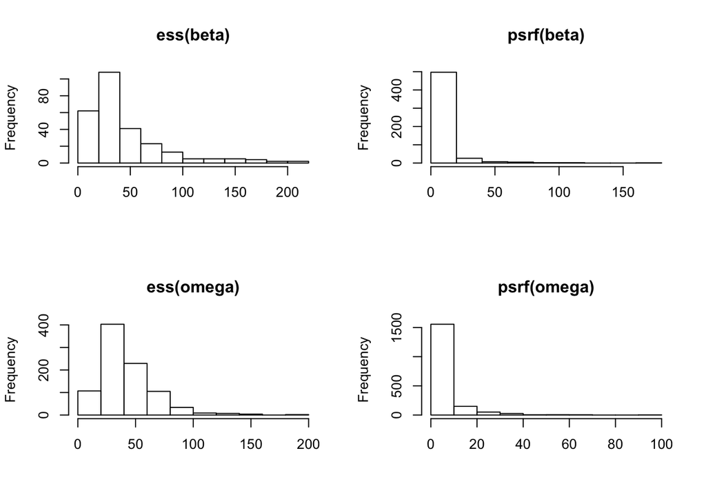

```r
mpost = convertToCodaObject(m)
par(mfrow=c(2,2))
hist(effectiveSize(mpost$Beta), main="ess(beta)",xlab="")
hist(gelman.diag(mpost$Beta,multivariate=FALSE)$psrf, main="psrf(beta)",xlab="")
hist(effectiveSize(mpost$Omega[[1]]), main="ess(omega)",xlab="")
hist(gelman.diag(mpost$Omega[[1]],multivariate=FALSE)$psrf, main="psrf(omega)",xlab="")
```

## Posterior estimates: the regression coefficients

We represent here the response of each species to the environement. We only show the coefficients whose credible interval does not overlap zero.

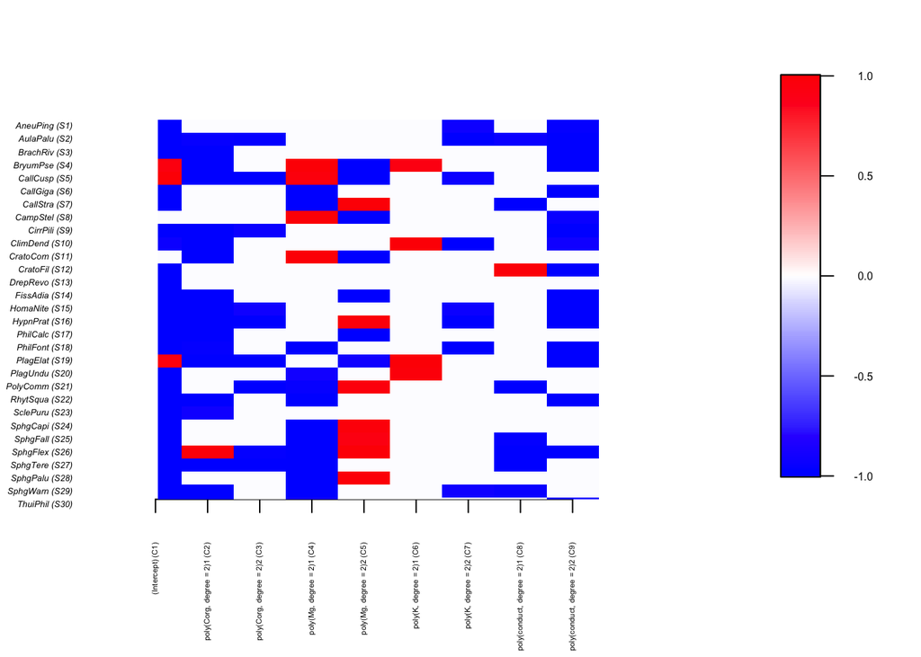

```r
postBeta = getPostEstimate(m, parName="Beta")
plotBeta(m, post=postBeta, param="Support", supportLevel = 0.95,cex = c(.35,.4,.5))
```

## Posterior estimates: species associations matrix

The species associations matrix is represented here, by showing only those values of the association matrix whose credible intervals do not overlap zero.

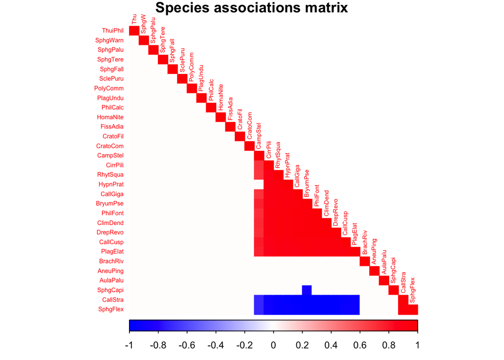

```r
OmegaCor = computeAssociations(m)
supportLevel = 0.95

toPlot = ((OmegaCor[[1]]$support>supportLevel)
          + (OmegaCor[[1]]$support<(1-supportLevel))>0)*OmegaCor[[1]]$mean
corrplot(toPlot, method = "color", col=colorRampPalette(c("blue","white","red"))(200), title=paste("Species associations matrix"), mar=c(0,0,1,0), type="lower",order = "hclust", tl.cex=0.5)
```

## Ordination

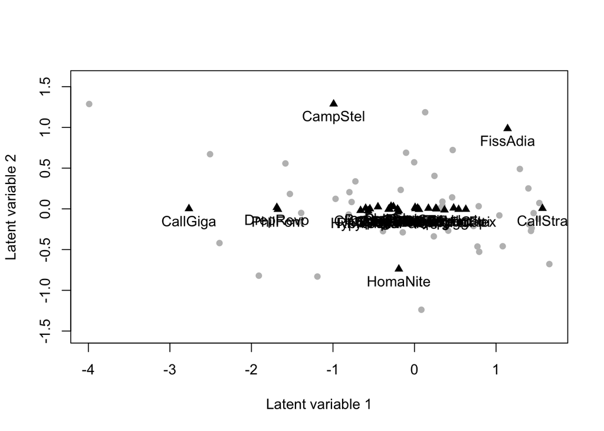

```r
etaPost = getPostEstimate(m, "Eta")
lambdaPost=getPostEstimate(m, "Lambda")
biPlot(m, etaPost = etaPost, lambdaPost=lambdaPost, factors=c(1,2))
```

## Model fit

```r
preds = computePredictedValues(m)
MF = evaluateModelFit(hM=m, predY=preds)

partition = createPartition(m, nfolds = 2)
preds = computePredictedValues(m, partition = partition, verbose=FALSE)
CV = evaluateModelFit(hM = m, predY = preds)

studyDesign_new = data.frame(sample = as.factor(1:nrow(X_test)))
rL_new = HmscRandomLevel(units = studyDesign_new$sample)
#predict unconditional on test
Uncond=predict(m, XData= X_test, study=studyDesign_new, ranLevels = list(sample=rL_new), expected=F)
meanUncond = apply(simplify2array(Uncond), 1:2,mean)

pred_test = sqrt(colSums((meanUncond-Y_test)^2)/nrow(Y_test))
```

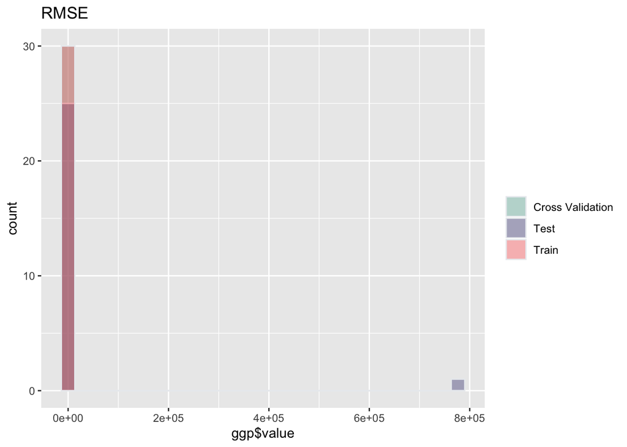

[output not shown]